# Regulation of drugs & professional practice

Adam La Caze School of Pharmacy The University of Queensland

Semester 1, 2022

## Learning Objectives

- Be aware of key federal and state laws regarding medicines
- Be able to describe what is meant by a drug schedule
- Be able to identify key responsibilities of medical practitioners in relation to drugs and poisons
- Be able to critically reflect on your practice and the practice of others in relation to drugs and poisons

## Key Concepts

- Medicines are tightly regulated. Two important legislative instruments are the *Standard for Uniform Scheduling for Medicines and Poisons* (SUSMP) and *Medicines and Poisons (Medicines) Regulation 2021* (MAPR)
  - Drugs are regulated according to **schedules**. The SUSMP provides the schedules for drugs in Australia.
  - MAPR stipulates the who, how, when and where of prescribing, dispensing and administration of drugs in Queensland
- Professional decisions rely on considerations of the law, ethics and the clinical context—it is rare that a professional decision can be made relying exclusively on any one of these

# Professional decision-making

## Professional decisions

- Professional decisions regarding screening, diagnosis and treatment take into consideration a wide array of factors
  - What is the evidence?
  - What does the patient want?
  - What is available to you?
  - What are you legally permitted to do?
  - What are you competent to do?
- These decisions have important consequences and *always* have an ethical component

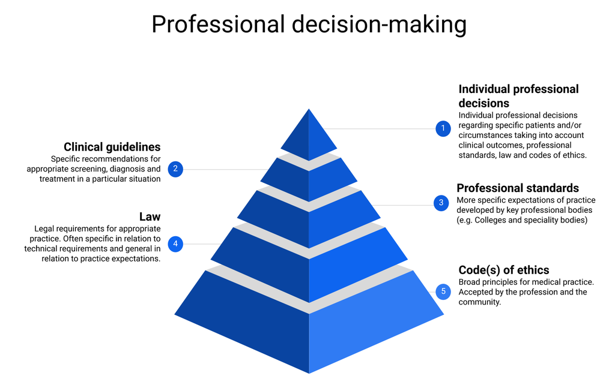

Appropriate individual professional decisions are informed by clinical guidelines, professional standards, legal requirements and code(s) of ethics

## A case

Samara is 35 and looks after 3 children. She suffers regular migraines, depression and anxiety. Samara presents to clinic asking for a script for her anxiety and pain tablets.

She is currently taking nitrazepam, diazepam, tramadol, amitriptyline and some antibiotics for a recent upper respiratory infection.

Looking at your records she has been coming more regularly than you would expect for her pain and anxiety tablets. One of your colleagues recently noted a concern that she was “relying on these medicines too much”.

## Some additional questions

- Can you/should you self-prescribe tramadol?
- Can you/should you self-prescribe ketamine?
- Can you/should you prescribe hydroxychloroquine to a family member?

# Medicines regulation

## Medical practice and regulation

Being a health professional means practising in accordance with the law.

Practising outside of the law puts the *public* at risk.

If that is not a good enough reason; practising outside the law puts *you* at risk.

Risk of civil litigation

Risk of professional [censure](http://en.wikipedia.org/wiki/Censure): unprofessional conduct/professional misconduct (perhaps leading to removal of registration).

Risk of prosecution in the courts for breaches of the HDPR

## Law and medicines

A lot of legislation is relevant to medical practice. We are focusing on those related to medicines.

- [*Medicines and Poisons Act 2019*](https://www.legislation.qld.gov.au/view/html/asmade/act-2019-026)
- [*Medicines and Poisons (Medicines) Regulation 2021*](https://www.health.qld.gov.au/system-governance/licences/medicines-poisons/medicines-poisons-act)
- *Standard for Uniform Scheduling for Medicines and Poisons* (referred to as: [SUSMP](http://www.tga.gov.au/industry/scheduling-poisons-standard.htm))
- [QH Departmental Standard: Monitored Medicines version 1](https://www.health.qld.gov.au/__data/assets/pdf_file/0029/1108937/ds-monitored-medicines.pdf)

The nice thing about legislation is that it is written down.

## Medicines regulation: overview

## Scheduling (SUSMP)

- Medicine scheduling is provided by the *Standard for the Uniform Scheduling of Medicines and Poisons* (SUSMP)
- Roughly speaking, the more dangerous the drug—due to toxicity or potential for abuse—the more restricted the scheduling.
- The regulations provided in the HDPR depend on the schedule of the medicine

## Key Schedules

Different terminology used for drug schedules. The SUSMP has schedule 1–9. S2–4 and S8 are the schedules that you most frequently come across in practice.

| SUSMP | MAPR | Alternatives | Examples |
| --- | --- | --- | --- |
| S2,S3 | Poisons | Over-the-counter drugs | Paracetamol |
| S4 | Restricted drug | Prescription drug | Antibiotics |
| S8 | Controlled drug | Dangerous drug | Opioids |

## *Medicines and Poisons (Medicines) Regulation 2021*

- MAPR prescribes who is **authorised** to undertake specific activities (**dealings**) with medicines
- Categories of medicines include
  - SUSMP schedules (S2, S3, S4, S8)
  - *Restricted medicines*
  - *High-risk medicines*
  - *Diversion-risk medicines*
  - *Monitored medicines*

## Categories of medicines

MAPR medicines categories with examples

| Category | Description | Examples |
| --- | --- | --- |
| Restricted medicines | Medicines that are restricted to specific specialities, or particular circumstances | Clomiphene, clozapine, etretinate |
| High-risk medicines | Medicines identified as potentially presenting a high risk of harm to patients as a result of misuse, abuse, diversion, substance use disorder and/or overdose | S8 medicines, benzodiazepines, codeine, gabapentin, pregabalin, quetiapine, tramadole, zolpidem, zopiclone |
| Diversion-risk medicines | Medicines at high-risk of misuse and/or diversion | High-risk medicines plus growth hormones, ephedrine, anabolic steroids, and more |
| Monitored medicines | High-risk medicines designated as requiring real-time monitoring | Same list is High-risk medicines |

## Doctors

Medical practitioners can prescribe, make a standing order, dispense, give a treatment dose, administer, repackage, give a purchase order, possess, dispose…. non-restricted medicines

Other health professionals: nurses, pharmacists, podiatrists, dentists, …, are *authorised* to perform subsets of these activities.

## *Regulated* restricted and controlled drugs

- Some drugs are subject to further regulations: regulated controlled drugs, regulated restricted drugs
- Typically this is limiting prescription of these drugs to particular medical specialties or indications

Examples include dexamphetamine, isotretinoin, …

## Requirements on a prescription

- The MAPR stipulates what needs to be on a legal prescription for controlled drugs (s87) and restricted drugs (s86)

Some of the **additional** items needed on a controlled drug prescription: single drug, patient’s date of birth, quantity in words and numbers

## Further restrictions on high-risk medicines

- See details in [Monitored Medicines Standard](https://www.health.qld.gov.au/__data/assets/pdf_file/0029/1108937/ds-monitored-medicines.pdf)

There are further restrictions in the *Medicines and Poisons Act 2019* (s40); prescribers can’t self-prescribe “unless the person has a reasonable excuse”

Additional guidance is provided in the Code of Conduct (9.2.2)

# Cases & questions

## A general model for decision-making

1. Identify the problem and possible consequences of the problem
2. Identify relevant law and professional standards that apply to the case
3. Identify the available options for resolving the problem and the reasons for or against each one
4. Formulate a plan of action to resolve the problem

## A case

Samara is 35 and looks after 3 children. She suffers regular migraines, depression and anxiety. Samara presents to the practice asking for a script for her anxiety and pain tablets.

She is currently taking nitrazepam, diazepam, tramadol, amitriptyline and some antibiotics for a recent upper respiratory infection.

Looking at your records she has been coming more regularly than you would expect for her pain and anxiety tablets. One of your colleagues recently noted a concern that she was “relying on these medicines too much”.

## Responding to the case

Responding to the case

| Model | Considerations |
| --- | --- |
| Problem and possible consequences | Medication use disorder; uncertainty regarding diagnosis; serious possible consequences |
| Relevant law and professional standards | Can provide legal prescription; professional standards in relation to medication use disorder are evolving |
| Options | Prescribe; extended consultation; refer |
| Plan | What do you do? |

## Case outcome

This example is based on one of the cases discussed in Forbes (2014).

The patient in this case died from drug misadventure with toxic levels of the anxiety and pain medications.

She was identified as a patient at risk of drug misadventure by multiple prescribers and her pharmacist, but there was limited discussion between them and both continued to prescribe and dispense.

## Some additional questions

- Can you/should you self-prescribe tramadol?
- Can you/should you self-prescribe ketamine?
- Can you/should you prescribe hydroxychloroquine to a family member?

## Further details

Responding to the additional questions

| Drug | Class | Category | Law/Guidance |
| --- | --- | --- | --- |
| Tramadol | Opioid | S4, monitored medicine | MAPR, Medicines and Poisons Act 2019, Code of conduct |
| Ketamine | NMDA antagonist | S8, monitored medicine | MAPR, Medicines and Poisons Act 2019, Code of conduct |
| Hydroxychloroquine | Antiprotozoal, DMARD | S4, restricted medicine | MAPR, Code of conduct |

# Conclusion

## Key Concepts

- Medicines are tightly regulated. Two important legislative instruments are the *Standard for Uniform Scheduling for Medicines and Poisons* (SUSMP) and *Medicines and Poisons (Medicines) Regulation 2021* (MAPR)
  - Drugs are regulated according to **schedules**. The SUSMP provides the schedules for drugs in Australia.
  - MAPR stipulates the who, how, when and where of prescribing, dispensing and administration of drugs in Queensland
- Professional decisions rely on considerations of the law, ethics and the clinical context—it is rare that a professional decision can be made relying exclusively on any one of these

## References

Coombes, I., Markwell, A., Kubler, P., Redmond, A. M., McGurk, G., & Roberts, J. A. (2020). Principles of ethical prescribing for self and others: Hydroxychloroquine in the COVID-19 pandemic. *Australian Prescriber*, *43*(3), 76–77. https://doi.org/10.18773/austprescr.2020.030

Forbes, C. (2014). *State Coroner’s Court of New South Wales: Inquest into the deaths of Christopher SALIB, Nathan ATTARD and Shamsad AKHTAR* (pp. 1–106). State Coroner’s Court of New South Wales.

Gould, S., & Norris, S. L. (2021). Contested effects and chaotic policies: the 2020 story of (hydroxy) chloroquine for treating COVID‐19. *Cochrane Database of Systematic Reviews*, *1*. https://doi.org/10.1002/14651858.ED000151

Winch, S., Milligan, E., & Rolley, A. (2014). Clinical ethics for emergency healthcare. In *Emergency and trauma care: for nurses and paramedics* (pp. 1–16).